# 重賞レース予測レポート【レース終了】

作成日時: 2026/05/24 19:46:40

☞ [マニュアル(pdf)](https://ryutoro-galois.github.io/keiba-predictor/manual/manual.pdf)

☞ 過去6年の同一レース結果: [2025年](https://ryutoro-galois.github.io/keiba-predictor/report/PredResult_2025y_raceDate_20250524_20250525.html), [2024年](https://ryutoro-galois.github.io/keiba-predictor/report/PredResult_2024y_raceDate_20240518_20240519.html), [2023年](https://ryutoro-galois.github.io/keiba-predictor/report/PredResult_2023y_raceDate_20230520_20230521.html), [2022年](https://ryutoro-galois.github.io/keiba-predictor/report/PredResult_2022y_raceDate_20220521_20220522.html), [2021年](https://ryutoro-galois.github.io/keiba-predictor/report/PredResult_2021y_raceDate_20210522_20210523.html), [2020年](https://ryutoro-galois.github.io/keiba-predictor/report/PredResult_2020y_raceDate_20200523_20200524.html)

☞ 過去4週間の別レース結果: [1週前(5/16-17)](https://ryutoro-galois.github.io/keiba-predictor/report/PredResult_2026y_raceDate_20260516_20260517.html), [2週前(5/9-10)](https://ryutoro-galois.github.io/keiba-predictor/report/PredResult_2026y_raceDate_20260509_20260510.html), [3週前(5/2-3)](https://ryutoro-galois.github.io/keiba-predictor/report/PredResult_2026y_raceDate_20260502_20260503.html), [4週前(4/25-26)](https://ryutoro-galois.github.io/keiba-predictor/report/PredResult_2026y_raceDate_20260425_20260426.html)

☞ netkeiba: [平安ステークス(GⅢ)](https://race.netkeiba.com/race/result.html?race_id=202608030911&rf=race_submenu), [優駿牝馬(GⅠ)](https://race.netkeiba.com/race/result.html?race_id=202605021011&rf=race_submenu)

☞ レース結果(csv): [5/23-24](https://ryutoro-galois.github.io/keiba-predictor/csv/race_result_20260523_20260524.csv)

## 【レース結果(1)】人気と着順の関係

### 【平安ステークス(2026/05/23(土))】

【平安ステークス(GⅢ)】  
2026/05/23(土), 08_京都, ダ右1900m

[interactive chart not shown]

### 【優駿牝馬(2026/05/24(日))】

【優駿牝馬(GⅠ)】  
2026/05/24(日), 05_東京, 芝左2400m

[interactive chart not shown]

## 【レース結果(2)】コーナー通過順位

### 【平安ステークス(2026/05/23(土))】

【平安ステークス(GⅢ)】  
2026/05/23(土), 08_京都, ダ右1900m

[interactive chart not shown]

### 【優駿牝馬(2026/05/24(日))】

【優駿牝馬(GⅠ)】  
2026/05/24(日), 05_東京, 芝左2400m

[interactive chart not shown]

## 0. 推し馬予測 (AI予測)

### 【平安ステークス(GⅢ) 2026/05/23(土)】

- 本命(◎): 1-3着内確率(勝負強さ)が1位の馬
- 対抗(◯): 1-3着内確率が2-N位(20%程度以上)の中で予測タイムが最も速い馬
- 3番手(▲): 1-3着内確率が2-N位(20%程度以上)のでダークホース確率が最も高い馬
- 穴: ダークホース確率が上位1-M位(40%程度以上)の中で1-3着内確率が最も高い馬

| 推し馬 | 枠番 | 馬番 | 人気 | オッズ | 馬名 | 騎手 | 調教師 | 予測タイム(sec) | 1_順位 | 1-3着内確率(%) | 2_順位 | ﾀﾞｰｸﾎｰｽ確率(%) | 3_順位 |
| --- | --- | --- | --- | --- | --- | --- | --- | --- | --- | --- | --- | --- | --- |
| 本命(◎) | 8 | 15 | 2 | 4.4 | ナルカミ | 戸崎圭太 | 田中博康 | 114.3 | 3 | 37.9 | 1 | 0.4 | 16 |
| 対抗(◯) | 6 | 11 | 4 | 11.3 | タイトニット | 川田将雅 | 今野貞一 | 114.7 | 6 | 23.0 | 3 | 1.2 | 12 |
| 3番手(▲) | 2 | 3 | 3 | 6.2 | リアライズカミオン | 坂井瑠星 | 堀宣行 | 120.7 | 7 | 25.8 | 2 | 1.1 | 13 |
| 穴 | 1 | 1 | 13 | 43.4 | ポッドロゴ | 岩田望来 | 西園翔太 | 114.3 | 4 | 11.0 | 7 | 44.0 | 2 |

### 【優駿牝馬(GⅠ) 2026/05/24(日)】

- 本命(◎): 1-3着内確率(勝負強さ)が1位の馬
- 対抗(◯): 1-3着内確率が2-N位(20%程度以上)の中で予測タイムが最も速い馬
- 3番手(▲): 1-3着内確率が2-N位(20%程度以上)のでダークホース確率が最も高い馬
- 穴: ダークホース確率が上位1-M位(40%程度以上)の中で1-3着内確率が最も高い馬

| 推し馬 | 枠番 | 馬番 | 人気 | オッズ | 馬名 | 騎手 | 調教師 | 予測タイム(sec) | 1_順位 | 1-3着内確率(%) | 2_順位 | ﾀﾞｰｸﾎｰｽ確率(%) | 3_順位 |
| --- | --- | --- | --- | --- | --- | --- | --- | --- | --- | --- | --- | --- | --- |
| 本命(◎) | 6 | 12 | 3 | 5.2 | ドリームコア | Ｃ．ルメール | 大竹正博 | 147.9 | 3.0 | 35.6 | 1 | 0.7 | 14 |
| 対抗(◯) | 5 | 10 | 1 | 3.0 | スターアニス | 松山弘平 | 高野友和 | 142.8 | 1.5 | 28.1 | 2 | 0.6 | 16 |
| 3番手(▲) | 7 | 15 | 7 | 33.7 | アンジュドジョワ | 岩田望来 | 福永祐一 | 150.2 | 10.5 | 27.7 | 3 | 1.5 | 12 |
| 穴 | 1 | 1 | 18 | 471.8 | ミツカネベネラ | 横山和生 | 鈴木伸尋 | 150.2 | 10.5 | 12.9 | 10 | 58.7 | 1 |

## 1. 予測チャート (タイム/勝負強さ)

### 【平安ステークス(GⅢ)】

2026/05/23(土), 08_京都, ダ右1900m

[interactive chart not shown]

### 【優駿牝馬(GⅠ)】

2026/05/24(日), 05_東京, 芝左2400m

[interactive chart not shown]

## 2. オッズモニタリング (毎時)

### 【平安ステークス】

[interactive chart not shown]

### 【優駿牝馬】

[interactive chart not shown]

## 3. 出馬表

### 【平安ステークス 2026/05/23(土) 】

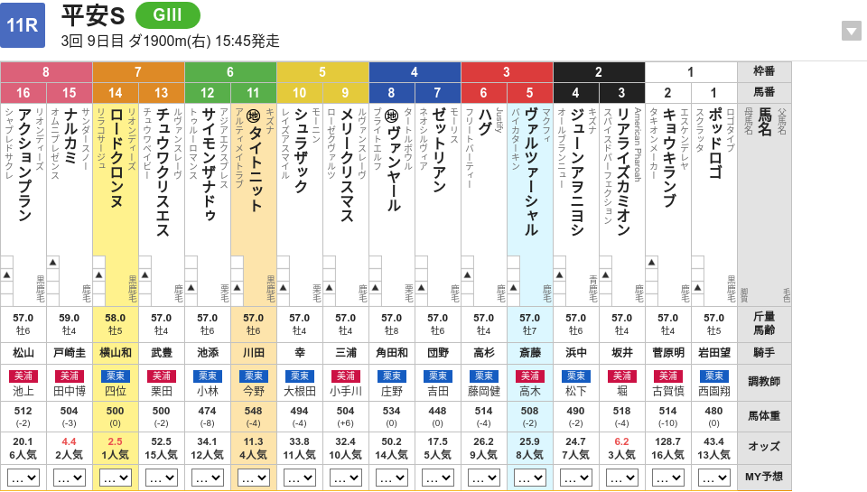

### 【優駿牝馬 2026/05/24(日) 】

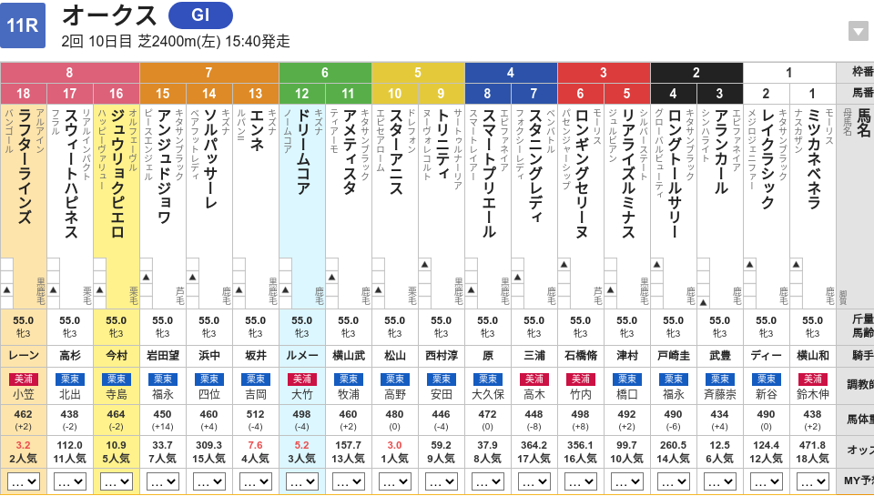

## 4. 単勝予測結果

### 【平安ステークス(GⅢ) 2026/05/23(土)】

| 枠番 | 馬番 | 人気 | オッズ | 馬名 | 騎手 | 調教師 | 予測タイム(sec) | 1_順位 | 1-3着内確率(%) | 2_順位 | ﾀﾞｰｸﾎｰｽ確率(%) | 3_順位 |
| --- | --- | --- | --- | --- | --- | --- | --- | --- | --- | --- | --- | --- |
| 1 | 1 | 13 | 43.4 | ポッドロゴ | 岩田望来 | 西園翔太 | 114.3 | 4 | 11.0 | 7 | 44.0 | 2 |
| 1 | 2 | 16 | 128.7 | キョウキランブ | 菅原明良 | 古賀慎明 | 122.5 | 9 | 3.3 | 14 | 11.9 | 6 |
| 2 | 3 | 3 | 6.2 | リアライズカミオン | 坂井瑠星 | 堀宣行 | 120.7 | 7 | 25.8 | 2 | 1.1 | 13 |
| 2 | 4 | 7 | 24.7 | ジューンアヲニヨシ | 浜中俊 | 松下武士 | 123.9 | 15 | 5.7 | 10 | 1.4 | 10 |
| 3 | 5 | 8 | 25.9 | ヴァルツァーシャル | 斎藤新 | 高木登 | 122.6 | 10 | 4.3 | 12 | 0.8 | 14 |
| 3 | 6 | 9 | 26.2 | ハグ | 高杉吏麒 | 藤岡健一 | 114.5 | 5 | 12.7 | 6 | 31.0 | 3 |
| 4 | 7 | 5 | 17.5 | ゼットリアン | 団野大成 | 吉田直弘 | 122.6 | 11 | 10.7 | 8 | 1.5 | 9 |
| 4 | 8 | 14 | 50.2 | ヴァンヤール | 角田大和 | 庄野靖志 | 126.2 | 16 | 8.1 | 9 | 53.0 | 1 |
| 5 | 9 | 10 | 32.4 | メリークリスマス | 三浦皇成 | 小手川準 | 113.2 | 2 | 13.4 | 5 | 29.8 | 4 |
| 5 | 10 | 11 | 33.8 | シュラザック | 幸英明 | 大根田裕之 | 123.0 | 13 | 2.5 | 16 | 10.1 | 8 |

[output cut: 6 more lines]

### 【優駿牝馬(GⅠ) 2026/05/24(日)】

| 枠番 | 馬番 | 人気 | オッズ | 馬名 | 騎手 | 調教師 | 予測タイム(sec) | 1_順位 | 1-3着内確率(%) | 2_順位 | ﾀﾞｰｸﾎｰｽ確率(%) | 3_順位 |
| --- | --- | --- | --- | --- | --- | --- | --- | --- | --- | --- | --- | --- |
| 1 | 1 | 18 | 471.8 | ミツカネベネラ | 横山和生 | 鈴木伸尋 | 150.2 | 10.5 | 12.9 | 10 | 58.7 | 1 |
| 1 | 2 | 12 | 124.4 | レイクラシック | Ｍ．ディー | 新谷功一 | 150.4 | 14.0 | 6.0 | 16 | 18.9 | 9 |
| 2 | 3 | 6 | 12.5 | アランカール | 武豊 | 斉藤崇史 | 150.2 | 10.5 | 27.3 | 4 | 0.6 | 15 |
| 2 | 4 | 14 | 260.5 | ロングトールサリー | 戸崎圭太 | 福永祐一 | 150.2 | 4.5 | 9.3 | 13 | 42.3 | 6 |
| 3 | 5 | 10 | 99.7 | リアライズルミナス | 津村明秀 | 橋口慎介 | 150.2 | 6.5 | 5.9 | 17 | 22.6 | 8 |
| 3 | 6 | 16 | 356.1 | ロンギングセリーヌ | 石橋脩 | 竹内正洋 | 150.2 | 6.5 | 7.0 | 15 | 48.2 | 4 |
| 4 | 7 | 17 | 364.2 | スタニングレディ | 三浦皇成 | 高木登 | 150.2 | 10.5 | 12.0 | 12 | 58.3 | 2 |
| 4 | 8 | 8 | 37.9 | スマートプリエール | 原優介 | 大久保龍志 | 150.2 | 10.5 | 18.5 | 8 | 1.8 | 11 |
| 5 | 9 | 9 | 59.2 | トリニティ | 西村淳也 | 安田翔伍 | 150.6 | 15.0 | 17.8 | 9 | 2.0 | 10 |
| 5 | 10 | 1 | 3.0 | スターアニス | 松山弘平 | 高野友和 | 142.8 | 1.5 | 28.1 | 2 | 0.6 | 16 |

[output cut: 8 more lines]

## 5. 人気と着順の乖離率推移

### 【平安ステークス_1994y_2019y】

[interactive chart not shown]

### 【優駿牝馬_1990y_2019y】

[interactive chart not shown]

### 【平安ステークス_1994y_2019y】

| No | 開催年 | 不整合率(%) | 頭数 | 人気別着順(1-3位) | 人気別着順(全体) |
| --- | --- | --- | --- | --- | --- |
| 26 | 2019 | 27.0 | 16頭 | 1-12-3 | 1\|12\|3\|4\|2\|7\|10\|9\|6\|11\|13\|5\|8\|16\|15\|14 |
| 25 | 2018 | 48.1 | 16頭 | 7-3-5 | 7\|3\|5\|6\|1\|2\|14\|13\|10\|11\|9\|4\|8\|16\|12\|15 |
| 24 | 2017 | 38.6 | 16頭 | 1-6-15 | 1\|6\|15\|9\|4\|8\|11\|13\|3\|2\|16\|5\|7\|10\|14\|12 |
| 23 | 2016 | 28.6 | 15頭 | 1-3-4 | 1\|3\|4\|13\|15\|7\|8\|6\|14\|2\|5\|9\|11\|10\|12 |
| 22 | 2015 | 60.1 | 16頭 | 4-3-5 | 4\|3\|5\|2\|1\|12\|10\|11\|7\|15\|6\|13\|14\|8\|9\|16 |
| 21 | 2014 | 45.5 | 16頭 | 12-7-4 | 12\|7\|4\|2\|1\|11\|8\|6\|9\|3\|16\|13\|15\|5\|10\|14 |
| 20 | 2013 | 31.3 | 16頭 | 1-8-5 | 1\|8\|5\|12\|3\|9\|2\|15\|4\|10\|16\|11\|14\|13\|6\|7 |
| 19 | 2012 | 37.1 | 16頭 | 10-1-6 | 10\|1\|6\|5\|7\|12\|3\|2\|13\|4\|14\|9\|15\|8\|16\|11 |
| 18 | 2011 | 36.5 | 16頭 | 2-3-4 | 2\|3\|4\|10\|1\|6\|7\|11\|13\|14\|8\|12\|15\|9\|5\|16 |
| 17 | 2010 | 48.3 | 11頭 | 5-1-7 | 5\|1\|7\|4\|6\|3\|9\|2\|11\|10\|8 |

[output cut: 16 more lines]

### 【優駿牝馬_1990y_2019y】

| No | 開催年 | 不整合率(%) | 頭数 | 人気別着順(1-3位) | 人気別着順(全体) |
| --- | --- | --- | --- | --- | --- |
| 30 | 2019 | 19.0 | 18頭 | 1-12-2 | 1\|12\|2\|6\|4\|7\|10\|13\|3\|17\|8\|5\|18\|14\|9\|11\|16\|15 |
| 29 | 2018 | 19.9 | 17頭 | 1-4-2 | 1\|4\|2\|11\|6\|3\|9\|12\|5\|8\|10\|16\|7\|13\|17\|14\|15 |
| 28 | 2017 | 18.4 | 18頭 | 1-6-2 | 1\|6\|2\|9\|3\|5\|17\|16\|8\|11\|14\|13\|4\|12\|15\|7\|18\|10 |
| 27 | 2016 | 18.9 | 18頭 | 1-2-5 | 1\|2\|5\|10\|8\|12\|11\|17\|6\|3\|4\|13\|7\|16\|9\|14\|15\|18 |
| 26 | 2015 | 43.5 | 17頭 | 3-1-6 | 3\|1\|6\|13\|7\|14\|4\|12\|5\|2\|11\|8\|15\|16\|17\|10\|9 |
| 25 | 2014 | 21.1 | 18頭 | 2-1-3 | 2\|1\|3\|17\|7\|10\|4\|9\|16\|11\|5\|15\|6\|14\|12\|8\|13\|18 |
| 24 | 2013 | 44.7 | 18頭 | 9-5-1 | 9\|5\|1\|3\|17\|14\|11\|13\|7\|18\|10\|4\|12\|6\|8\|15\|2\|16 |
| 23 | 2012 | 51.3 | 18頭 | 3-2-9 | 3\|2\|9\|4\|17\|8\|5\|13\|6\|11\|15\|10\|1\|7\|18\|12\|14\|16 |
| 22 | 2011 | 38.9 | 18頭 | 7-8-2 | 7\|8\|2\|1\|14\|6\|10\|17\|4\|11\|9\|16\|12\|3\|15\|18\|5\|13 |
| 21 | 2010 | 39.8 | 18頭 | 1-5-8 | 1\|5\|8\|11\|3\|4\|14\|12\|15\|9\|6\|13\|17\|7\|10\|18\|2\|16 |

[output cut: 20 more lines]

## 6. 1-3番人気馬の着順分類予測

### 【平安ステークス】

| 分類 | 凡例 | 発生確率(%) | 当該レース | 当該レースランク | 直近1年間 |
| --- | --- | --- | --- | --- | --- |
| 1: 1番人気のみ (1_pop1) | 1 \| * \| * | 17.7 | 0.81 | 0.81 | 0.00 |
| 4: 1,2番人気のみ (4_pop12) | 1 \| 2 \| * | 17.6 | 2.84 | 2.84 | 0.35 |
| 5: 1,3番人気のみ (5_pop13) | 1 \| 3 \| * | 16.9 | 0.54 | 0.54 | 0.34 |
| 8: 1,2,3番人気すべて着外 (8_darkhorse) | * \| * \| * | 13.8 | 2.23 | 2.23 | 0.00 |
| 6: 2,3番人気のみ (6_pop23) | 2 \| 3 \| * | 9.8 | 1.58 | 1.58 | 0.00 |
| 2: 2番人気のみ (2_pop2) | 2 \| * \| * | 9.1 | 0.97 | 0.97 | 0.00 |
| 3: 3番人気のみ (3_pop3) | 3 \| * \| * | 8.2 | 0.53 | 0.53 | 0.00 |
| 7: 1,2,3番人気すべて着内 (7_pop123) | 1 \| 2 \| 3 | 6.9 | 2.23 | 2.23 | 0.00 |

### 【優駿牝馬】

| 分類 | 凡例 | 発生確率(%) | 当該レース | 当該レースランク | 直近1年間 |
| --- | --- | --- | --- | --- | --- |
| 1: 1番人気のみ (1_pop1) | 1 \| * \| * | 17.7 | 1.06 | 1.06 | 0.00 |
| 4: 1,2番人気のみ (4_pop12) | 1 \| 2 \| * | 17.6 | 0.49 | 0.49 | 0.18 |
| 5: 1,3番人気のみ (5_pop13) | 1 \| 3 \| * | 16.9 | 2.04 | 2.04 | 0.00 |
| 8: 1,2,3番人気すべて着外 (8_darkhorse) | * \| * \| * | 13.8 | 2.46 | 2.46 | 0.00 |
| 6: 2,3番人気のみ (6_pop23) | 2 \| 3 \| * | 9.8 | 3.50 | 3.50 | 0.00 |
| 2: 2番人気のみ (2_pop2) | 2 \| * \| * | 9.1 | 0.54 | 0.54 | 0.00 |
| 3: 3番人気のみ (3_pop3) | 3 \| * \| * | 8.2 | 1.46 | 1.46 | 0.00 |
| 7: 1,2,3番人気すべて着内 (7_pop123) | 1 \| 2 \| 3 | 6.9 | 0.83 | 0.83 | 0.00 |

## 7. 3連複予測結果

### 【平安ステークス(GⅢ) 2026/05/23(土)】

| 分類 | 馬番 | 枠番 | 人気 | 平均予測タイム(sec) | 1-3着内確率(%) | ﾀﾞｰｸﾎｰｽ確率(%) | 馬名 | 騎手 | 調教師 |
| --- | --- | --- | --- | --- | --- | --- | --- | --- | --- |
| 6: 2,3番人気のみ (6_pop23) | 15-3-11 | 8-2-6 | 2-3-4 | 116.57 | 2.25 | 0.00 | ナルカミ \| リアライズカミオン \| タイトニット | 戸崎圭太 \| 坂井瑠星 \| 川田将雅 | 田中博康 \| 堀宣行 \| 今野貞一 |
| 7: 1,2,3番人気すべて着内 (7_pop123) | 14-15-3 | 7-8-2 | 1-2-3 | 114.37 | 1.60 | 0.00 | ロードクロンヌ \| ナルカミ \| リアライズカミオン | 横山和生 \| 戸崎圭太 \| 坂井瑠星 | 四位洋文 \| 田中博康 \| 堀宣行 |
| 4: 1,2番人気のみ (4_pop12) | 14-15-11 | 7-8-6 | 1-2-4 | 112.37 | 1.42 | 0.00 | ロードクロンヌ \| ナルカミ \| タイトニット | 横山和生 \| 戸崎圭太 \| 川田将雅 | 四位洋文 \| 田中博康 \| 今野貞一 |
| 6: 2,3番人気のみ (6_pop23) | 15-3-9 | 8-2-5 | 2-3-10 | 116.07 | 1.31 | 0.00 | ナルカミ \| リアライズカミオン \| メリークリスマス | 戸崎圭太 \| 坂井瑠星 \| 三浦皇成 | 田中博康 \| 堀宣行 \| 小手川準 |
| 6: 2,3番人気のみ (6_pop23) | 15-3-6 | 8-2-3 | 2-3-9 | 116.50 | 1.24 | 0.00 | ナルカミ \| リアライズカミオン \| ハグ | 戸崎圭太 \| 坂井瑠星 \| 高杉吏麒 | 田中博康 \| 堀宣行 \| 藤岡健一 |
| 2: 2番人気のみ (2_pop2) | 15-11-9 | 8-6-5 | 2-4-10 | 114.07 | 1.16 | 0.00 | ナルカミ \| タイトニット \| メリークリスマス | 戸崎圭太 \| 川田将雅 \| 三浦皇成 | 田中博康 \| 今野貞一 \| 小手川準 |
| 2: 2番人気のみ (2_pop2) | 15-11-6 | 8-6-3 | 2-4-9 | 114.50 | 1.11 | 0.00 | ナルカミ \| タイトニット \| ハグ | 戸崎圭太 \| 川田将雅 \| 高杉吏麒 | 田中博康 \| 今野貞一 \| 藤岡健一 |
| 6: 2,3番人気のみ (6_pop23) | 15-3-1 | 8-2-1 | 2-3-13 | 116.43 | 1.08 | 0.00 | ナルカミ \| リアライズカミオン \| ポッドロゴ | 戸崎圭太 \| 坂井瑠星 \| 岩田望来 | 田中博康 \| 堀宣行 \| 西園翔太 |
| 6: 2,3番人気のみ (6_pop23) | 15-3-7 | 8-2-4 | 2-3-5 | 119.20 | 1.05 | 0.00 | ナルカミ \| リアライズカミオン \| ゼットリアン | 戸崎圭太 \| 坂井瑠星 \| 団野大成 | 田中博康 \| 堀宣行 \| 吉田直弘 |
| 5: 1,3番人気のみ (5_pop13) | 14-3-11 | 7-2-6 | 1-3-4 | 114.50 | 0.97 | 0.00 | ロードクロンヌ \| リアライズカミオン \| タイトニット | 横山和生 \| 坂井瑠星 \| 川田将雅 | 四位洋文 \| 堀宣行 \| 今野貞一 |

[output cut: 550 more lines]

### 【優駿牝馬(GⅠ) 2026/05/24(日)】

| 分類 | 馬番 | 枠番 | 人気 | 平均予測タイム(sec) | 1-3着内確率(%) | ﾀﾞｰｸﾎｰｽ確率(%) | 馬名 | 騎手 | 調教師 |
| --- | --- | --- | --- | --- | --- | --- | --- | --- | --- |
| 5: 1,3番人気のみ (5_pop13) | 10-12-15 | 5-6-7 | 1-3-7 | 146.97 | 2.77 | 0.00 | スターアニス \| ドリームコア \| アンジュドジョワ | 松山弘平 \| Ｃ．ルメール \| 岩田望来 | 高野友和 \| 大竹正博 \| 福永祐一 |
| 5: 1,3番人気のみ (5_pop13) | 10-12-3 | 5-6-2 | 1-3-6 | 146.97 | 2.73 | 0.00 | スターアニス \| ドリームコア \| アランカール | 松山弘平 \| Ｃ．ルメール \| 武豊 | 高野友和 \| 大竹正博 \| 斉藤崇史 |
| 5: 1,3番人気のみ (5_pop13) | 10-12-13 | 5-6-7 | 1-3-4 | 147.13 | 2.71 | 0.00 | スターアニス \| ドリームコア \| エンネ | 松山弘平 \| Ｃ．ルメール \| 坂井瑠星 | 高野友和 \| 大竹正博 \| 吉岡辰弥 |
| 3: 3番人気のみ (3_pop3) | 12-3-15 | 6-2-7 | 3-6-7 | 149.43 | 2.69 | 0.00 | ドリームコア \| アランカール \| アンジュドジョワ | Ｃ．ルメール \| 武豊 \| 岩田望来 | 大竹正博 \| 斉藤崇史 \| 福永祐一 |
| 3: 3番人気のみ (3_pop3) | 12-13-15 | 6-7-7 | 3-4-7 | 149.60 | 2.67 | 0.00 | ドリームコア \| エンネ \| アンジュドジョワ | Ｃ．ルメール \| 坂井瑠星 \| 岩田望来 | 大竹正博 \| 吉岡辰弥 \| 福永祐一 |
| 3: 3番人気のみ (3_pop3) | 12-13-3 | 6-7-2 | 3-4-6 | 149.60 | 2.63 | 0.00 | ドリームコア \| エンネ \| アランカール | Ｃ．ルメール \| 坂井瑠星 \| 武豊 | 大竹正博 \| 吉岡辰弥 \| 斉藤崇史 |
| 5: 1,3番人気のみ (5_pop13) | 10-12-16 | 5-6-8 | 1-3-5 | 148.70 | 2.25 | 0.00 | スターアニス \| ドリームコア \| ジュウリョクピエロ | 松山弘平 \| Ｃ．ルメール \| 今村聖奈 | 高野友和 \| 大竹正博 \| 寺島良 |
| 7: 1,2,3番人気すべて着内 (7_pop123) | 10-18-12 | 5-8-6 | 1-2-3 | 144.50 | 2.22 | 0.00 | スターアニス \| ラフターラインズ \| ドリームコア | 松山弘平 \| Ｄ．レーン \| Ｃ．ルメール | 高野友和 \| 小笠倫弘 \| 大竹正博 |
| 3: 3番人気のみ (3_pop3) | 12-16-15 | 6-8-7 | 3-5-7 | 151.17 | 2.21 | 0.00 | ドリームコア \| ジュウリョクピエロ \| アンジュドジョワ | Ｃ．ルメール \| 今村聖奈 \| 岩田望来 | 大竹正博 \| 寺島良 \| 福永祐一 |
| 6: 2,3番人気のみ (6_pop23) | 18-12-15 | 8-6-7 | 2-3-7 | 146.97 | 2.18 | 0.00 | ラフターラインズ \| ドリームコア \| アンジュドジョワ | Ｄ．レーン \| Ｃ．ルメール \| 岩田望来 | 小笠倫弘 \| 大竹正博 \| 福永祐一 |

[output cut: 806 more lines]

## 8. 直近の全レース情報

[output not shown]

[output cut: 11 more lines]